# DATA 607 Project 2 Part 3

Subhalaxmi Rout

03/08/2020

# State Marriage Rates

Discussion thread created by : Gabriel Abreu

## 1. Introduction

These gives state marriage rates breaking down the data into regions and years. We can group the data by census region or census division. Then organize the rates according to year, changing it from wide data to long data.

URL: [Dataset link](https://data.world/siyeh/state-marriage-rate)

## 2.Load library

```r
#install.packages("dplyr")
#install.packages("tidyr")
#install.packages("ggplot2")
#install.packages("DT")
library(dplyr)
library(tidyr)
library(ggplot2)
library(DT)
```

## 3. Data load and cleaning

Data is stored in the **Github** and loaded data from Github to Rstudio using **read.csv()** method.

```r
# read csv file data in a variable using  read.csv
data <- read.csv('https://raw.githubusercontent.com/SubhalaxmiRout002/Data-607-Project-2-Dataset-1/master/marriage_rates_project.csv', header = TRUE, stringsAsFactors = F)

# convert data to data frame
data <- data.frame(data)

# display data using datatable
datatable(data,options = list(scrollX = TRUE, paging=TRUE,fixedHeader=TRUE))
```

|  | state | census_division | census_region | X2016 | X2015 | X2014 | X2013 | X2012 | X2011 | X2010 | X2009 | X2008 | X2007 | X2006 | X2005 | X2004 | X2003 | X2002 | X2001 | X2000 | X1999 | X1995 | X1990 |
| --- | --- | --- | --- | --- | --- | --- | --- | --- | --- | --- | --- | --- | --- | --- | --- | --- | --- | --- | --- | --- | --- | --- | --- |
| 1 | Alabama | East South Central | South | 7.1478 | 7.3515 | 7.8068 | 7.8178 | 8.2 | 8.4 | 8.2 | 8.3 | 8.6 | 8.9 | 9.2 | 9.2 | 9.4 | 9.6 | 9.9 | 9.4 | 10.1 | 10.8 | 9.8 | 10.6 |
| 2 | Alaska | Pacific | West | 7.1034 | 7.4076 | 7.5088 | 7.2939 | 7.2 | 7.8 | 8 | 7.8 | 8.4 | 8.5 | 8.2 | 8.2 | 8.5 | 8.1 | 8.3 | 8.1 | 8.9 | 8.6 | 9 | 10.2 |
| 3 | Arizona | Mountain | West | 5.9305 | 5.9225 | 5.7804 | 5.4011 | 5.6 | 5.7 | 5.9 | 5.6 | 6 | 6.4 | 6.5 | 6.6 | 6.7 | 6.5 | 6.7 | 7.6 | 7.5 | 8.2 | 8.8 | 10 |
| 4 | Arkansas | West South Central | South | 9.861 | 10.0403 | 10.112 | 9.7511 | 10.9 | 10.4 | 10.8 | 10.7 | 10.6 | 12 | 12.4 | 12.9 | 13.4 | 13.4 | 14.3 | 14.3 | 15.4 | 14.8 | 14.4 | 15.3 |
| 5 | California | Pacific | West | 6.4636 | 6.185 | 6.4415 | 6.4605 | 6 | 5.8 | 5.8 | 5.8 | 6.7 | 6.2 | 6.3 | 6.4 | 6.4 | 6.1 | 6.2 | 6.5 | 5.8 | 6.4 | 6.3 | 7.9 |
| 6 | Colorado | Mountain | West | 7.4254 | 6.7918 | 7.0616 | 6.4527 | 6.8 | 7 | 6.9 | 6.9 | 7.4 | 7.1 | 7.2 | 7.6 | 7.4 | 7.8 | 8 | 8.2 | 8.3 | 8.2 | 9 | 9.8 |
| 7 | Connecticut | New England | Northeast | 5.6179 | 5.292 | 5.3688 | 5.021 | 5.2 | 5.5 | 5.6 | 5.9 | 5.4 | 5.5 | 5.5 | 5.8 | 5.8 | 5.5 | 5.7 | 5.4 | 5.7 | 5.8 | 6.6 | 7.9 |
| 8 | Delaware | South Atlantic | South | 5.6131 | 5.7129 | 6.0228 | 6.572 | 5.8 | 5.2 | 5.2 | 5.4 | 5.5 | 5.7 | 5.9 | 5.9 | 6.1 | 6 | 6.4 | 6.5 | 6.5 | 6.7 | 7.3 | 8.4 |
| 9 | District of Columbia |  |  | 8.1492 | 8.2204 | 11.8213 | 10.7913 | 8.4 | 8.7 | 7.6 | 4.7 | 4.1 | 4.2 | 4 | 4.1 | 5.2 | 5.1 | 5.1 | 6.2 | 4.9 | 6.6 | 6.1 | 8.2 |
| 10 | Florida | South Atlantic | South | 8.126 | 8.2344 | 7.3014 | 7.0096 | 7.2 | 7.4 | 7.3 | 7.5 | 8 | 8.5 | 8.6 | 8.9 | 9 | 9 | 9.4 | 9.3 | 8.9 | 8.7 | 9.9 | 10.9 |

[output cut: 41 more lines]

### 3.1 Gather year from 1990 to 2016

This dataset year has given from 1990 to 2016. Each year mentioned as a column. Using **tidyr** convert these columns to `Year` column.

```r
# using gather() convert column to row
data <- data %>% gather(Year, Marriage_Rate, X2016:X1990, na.rm = TRUE)

# remove "X" from the year
data$Year  <- sub('X','',data$Year)

# arrange Marriage_Rate by desc order
data <- data %>% arrange(desc(Marriage_Rate))

# round Marriage Rate till 2 decimal
data$Marriage_Rate  <- round(data$Marriage_Rate,2)

# display data using datatable
datatable(data,options = list(scrollX = TRUE, paging=TRUE,fixedHeader=TRUE))
```

|  | state | census_division | census_region | Year | Marriage_Rate |
| --- | --- | --- | --- | --- | --- |
| 1 | Nevada | Mountain | West | 1990 | 99 |
| 2 | Nevada | Mountain | West | 1995 | 85.2 |
| 3 | Nevada | Mountain | West | 1999 | 82.3 |
| 4 | Nevada | Mountain | West | 2000 | 72.2 |
| 5 | Nevada | Mountain | West | 2001 | 69.6 |
| 6 | Nevada | Mountain | West | 2002 | 67.4 |
| 7 | Nevada | Mountain | West | 2003 | 63.9 |
| 8 | Nevada | Mountain | West | 2004 | 62.1 |
| 9 | Nevada | Mountain | West | 2005 | 57.4 |
| 10 | Nevada | Mountain | West | 2006 | 52.1 |

[output cut: 1003 more lines]

### 3.2 Rename column name

```r
# rename census_divison and census_region i.e "Division" and "Region"
data <- data %>% rename( Division = census_division,Region = census_region)

# replace null value to NA
data$Region[data$Region == ""] <- NA

# display data using datatable
datatable(data,options = list(scrollX = TRUE, paging=TRUE,fixedHeader=TRUE))
```

|  | state | Division | Region | Year | Marriage_Rate |
| --- | --- | --- | --- | --- | --- |
| 1 | Nevada | Mountain | West | 1990 | 99 |
| 2 | Nevada | Mountain | West | 1995 | 85.2 |
| 3 | Nevada | Mountain | West | 1999 | 82.3 |
| 4 | Nevada | Mountain | West | 2000 | 72.2 |
| 5 | Nevada | Mountain | West | 2001 | 69.6 |
| 6 | Nevada | Mountain | West | 2002 | 67.4 |
| 7 | Nevada | Mountain | West | 2003 | 63.9 |
| 8 | Nevada | Mountain | West | 2004 | 62.1 |
| 9 | Nevada | Mountain | West | 2005 | 57.4 |
| 10 | Nevada | Mountain | West | 2006 | 52.1 |

[output cut: 1003 more lines]

### 3.3 Region wise Marriage rate

Apply group by on Region and plot the graph using region wise marriage rate.

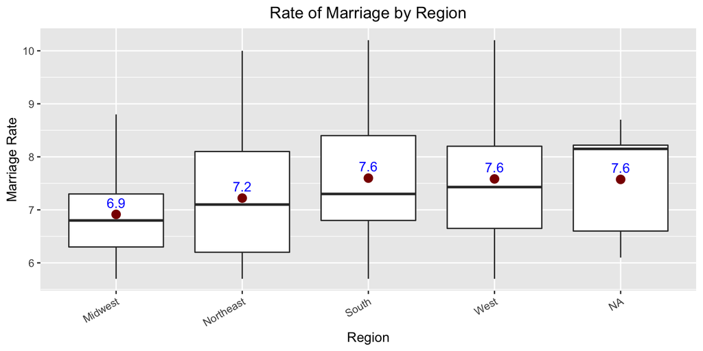

```r
#load data in a data frame
data1 <- data.frame(data)


#apply groupby on Region
data1 <- data1 %>% group_by(Region, Year) %>% select(Region,Year, Marriage_Rate)

#  Boxplot to analyse marriage rate
ggplot(data1,aes(x = Region, y = Marriage_Rate)) +
  geom_boxplot(outlier.shape = NA) +
scale_y_continuous(limits = quantile(data1$Marriage_Rate, c(0.1, 0.9))) +
stat_summary(fun=mean, colour="darkred", geom="point", size=3,show.legend = FALSE) +
stat_summary(fun=mean, colour="blue", geom="text", show.legend = FALSE,
               vjust=-0.7, aes( label=round(..y.., digits=1))) +
  xlab("Region") + ylab("Marriage Rate") +
theme(axis.text.x=element_text(angle=30,hjust=1),plot.title = element_text(hjust = 0.5)) +
  ggtitle("Rate of Marriage by Region")
```

```r
# get all unique Division
Regions = unique(data1$Region)
Regions
```

```
## [1] "West"      "South"     NA          "Midwest"   "Northeast"
```

```r
# summary for all Region
data4 <- data1 %>%
  group_by(Region) %>%
  summarize(Min. = min(Marriage_Rate),
            "1st Qu." = round(quantile(Marriage_Rate, 0.25),2),
            Median = round(median(Marriage_Rate),2),
            Mean = round(mean(Marriage_Rate),2),
            "3rd Qu." = round(quantile(Marriage_Rate, 0.75),2),
            Max. = max(Marriage_Rate)
            )
# display summary using datatable
datatable(data4,options = list(scrollX = TRUE, paging=TRUE,fixedHeader=TRUE))
```

|  | Region | Min. | 1st Qu. | Median | Mean | 3rd Qu. | Max. |
| --- | --- | --- | --- | --- | --- | --- | --- |
| 1 | Midwest | 5.22 | 6.1 | 6.7 | 6.79 | 7.2 | 11.1 |
| 2 | Northeast | 4.8 | 5.76 | 6.7 | 6.87 | 7.8 | 10.9 |
| 3 | South | 4.8 | 6.82 | 7.42 | 8.13 | 9 | 15.9 |
| 4 | West | 4 | 6.9 | 7.8 | 12.16 | 9.83 | 99 |
| 5 |  | 4 | 4.85 | 6.15 | 6.61 | 8.21 | 11.82 |

### 3.4 Division wise Marriage rate

Apply group by on Division and plot the graph using region wise marriage rate.

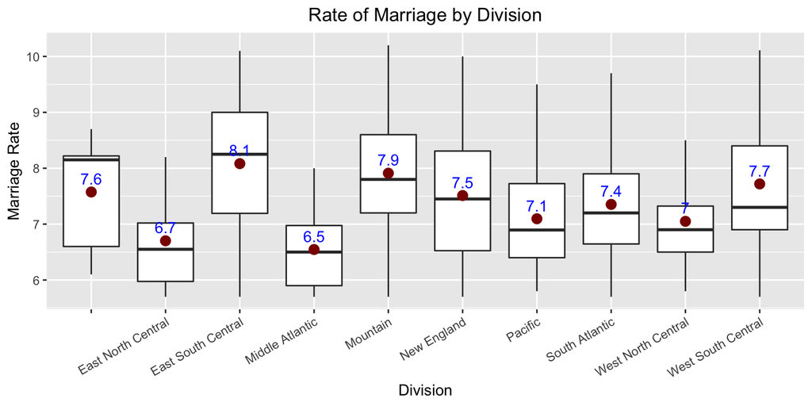

```r
#load data in a data frame
data2 <- data.frame(data)


#apply groupby on Region
data2 <- data2 %>% group_by(Division, Year) %>% select(Division,Year, Marriage_Rate)

# replace null value to NA
data$Division[data$Division == ""] <- NA

# plot line chart to analyse trend
ggplot(data2,aes(x = Division, y = Marriage_Rate)) +
  geom_boxplot(outlier.shape = NA) +
  scale_y_continuous(limits = quantile(data2$Marriage_Rate, c(0.1, 0.9))) +
stat_summary(fun=mean, colour="darkred", geom="point", size=3,show.legend = FALSE) +
stat_summary(fun=mean, colour="blue", geom="text", show.legend = FALSE,
               vjust=-0.7, aes( label=round(..y.., digits=1))) +
xlab("Division") + ylab("Marriage Rate") +
theme(axis.text.x=element_text(angle=30,hjust=1),plot.title = element_text(hjust = 0.5)) +
  ggtitle("Rate of Marriage by Division")
```

```r
# get all unique Division
Divisions = unique(data2$Division)
Divisions
```

```
##  [1] "Mountain"           "Pacific"            "South Atlantic"
##  [4] "East South Central" "West South Central" ""
##  [7] "West North Central" "New England"        "East North Central"
## [10] "Middle Atlantic"
```

```r
# summary for all division
data3 <- data2 %>%
  group_by(Division) %>%
  summarize(Min. = min(Marriage_Rate),
            "1st Qu." = round(quantile(Marriage_Rate, 0.25),2),
            Median = round(median(Marriage_Rate),2),
            Mean = round(mean(Marriage_Rate),2),
            "3rd Qu." = round(quantile(Marriage_Rate, 0.75),2),
            Max. = max(Marriage_Rate)
            )
# display data using datatable
datatable(data3,options = list(scrollX = TRUE, paging=TRUE,fixedHeader=TRUE))
```

|  | Division | Min. | 1st Qu. | Median | Mean | 3rd Qu. | Max. |
| --- | --- | --- | --- | --- | --- | --- | --- |
| 1 |  | 4 | 4.85 | 6.15 | 6.61 | 8.21 | 11.82 |
| 2 | East North Central | 5.22 | 5.8 | 6.25 | 6.5 | 7 | 9.6 |
| 3 | East South Central | 4.8 | 7.19 | 8.43 | 8.74 | 9.65 | 15.5 |
| 4 | Middle Atlantic | 4.8 | 5.58 | 5.9 | 6.18 | 6.8 | 8.6 |
| 5 | Mountain | 4 | 7.32 | 8.08 | 13.86 | 10 | 99 |
| 6 | New England | 5.02 | 5.9 | 7.14 | 7.22 | 8.3 | 10.9 |
| 7 | Pacific | 5.8 | 6.46 | 7.2 | 9.44 | 8.67 | 22.6 |
| 8 | South Atlantic | 5.2 | 6.6 | 7.2 | 7.45 | 8.12 | 15.9 |
| 9 | West North Central | 5.3 | 6.49 | 6.82 | 7 | 7.3 | 11.1 |
| 10 | West South Central | 5.7 | 7.09 | 8 | 8.89 | 10.07 | 15.4 |

## 4. Analysis

We will analyze, yealy Marriage rate over Division and Region. We will look the trend, how the trend is changing over 26 years.

### 4.1 Yealy Average Marriage Rate over Division

```r
# group by data by Division and Year
data5 <- data.frame(data) %>% group_by(Division, Year) %>% summarise(mean(Marriage_Rate)) %>% filter(!is.na(Division))

# rename Avg Marriage Rate column
data5 <- data5 %>% rename( Avg_Marriage_Rate = `mean(Marriage_Rate)`)

# round Avg_Marriage_Rate till 2 decimal places
data5$Avg_Marriage_Rate <- round(data5$Avg_Marriage_Rate,2)

# display data using datatable
datatable(data5,options = list(scrollX = TRUE, paging=TRUE,fixedHeader=TRUE))
```

|  | Division | Year | Avg_Marriage_Rate |
| --- | --- | --- | --- |
| 1 | East North Central | 1990 | 8.7 |
| 2 | East North Central | 1995 | 7.56 |
| 3 | East North Central | 1999 | 7.28 |
| 4 | East North Central | 2000 | 7.2 |
| 5 | East North Central | 2001 | 7.1 |
| 6 | East North Central | 2002 | 6.86 |
| 7 | East North Central | 2003 | 6.56 |
| 8 | East North Central | 2004 | 6.6 |
| 9 | East North Central | 2005 | 6.3 |
| 10 | East North Central | 2006 | 6.28 |

[output cut: 170 more lines]

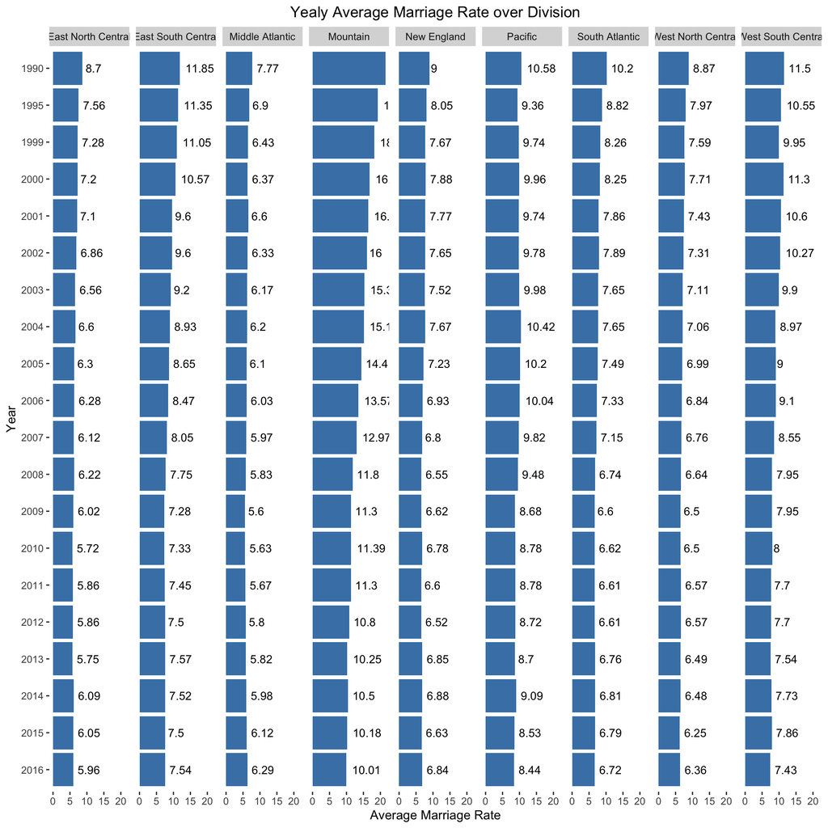

```r
ggplot(data5, aes(x = reorder(Year, desc(Year)), y = Avg_Marriage_Rate)) +
  geom_bar(stat = "identity",fill = "steelblue") + facet_grid(~Division) + coord_flip() +
  xlab("Year") + ylab("Average Marriage Rate")+ggtitle("Yealy Average Marriage Rate over Division") +
  theme(plot.title = element_text(hjust = 0.5),panel.background = element_rect(fill = "white", color = NA)) +
  geom_text(aes( y = Avg_Marriage_Rate,label=Avg_Marriage_Rate), hjust = -0.20, color="black", size=3.5)
```

### 4.2 Yealy Average Marriage Rate over Region

```r
# group by data by Division and Year
data6 <- data.frame(data) %>% group_by(Region, Year) %>% summarise(mean(Marriage_Rate)) %>% filter(!is.na(Region))

# rename Avg Marriage Rate column
data6 <- data6 %>% rename( Avg_Marriage_Rate = `mean(Marriage_Rate)`)

# round Avg_Marriage_Rate till 2 decimal places
data6$Avg_Marriage_Rate <- round(data6$Avg_Marriage_Rate,2)

# display data using datatable
datatable(data6,options = list(scrollX = TRUE, paging=TRUE,fixedHeader=TRUE))
```

|  | Region | Year | Avg_Marriage_Rate |
| --- | --- | --- | --- |
| 1 | Midwest | 1990 | 8.8 |
| 2 | Midwest | 1995 | 7.8 |
| 3 | Midwest | 1999 | 7.46 |
| 4 | Midwest | 2000 | 7.5 |
| 5 | Midwest | 2001 | 7.29 |
| 6 | Midwest | 2002 | 7.12 |
| 7 | Midwest | 2003 | 6.88 |
| 8 | Midwest | 2004 | 6.87 |
| 9 | Midwest | 2005 | 6.7 |
| 10 | Midwest | 2006 | 6.61 |

[output cut: 70 more lines]

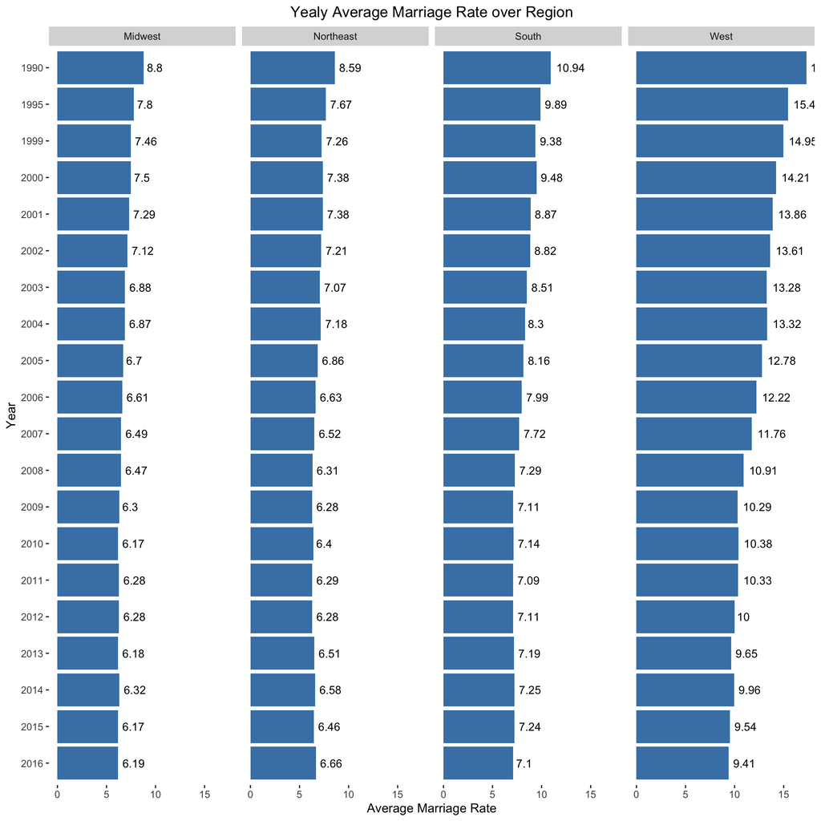

```r
ggplot(data6, aes(x = reorder(Year, desc(Year)), y = Avg_Marriage_Rate)) +
  geom_bar(stat = "identity",fill = "steelblue") + facet_grid(~Region) + coord_flip() +
  xlab("Year") + ylab("Average Marriage Rate")+ggtitle("Yealy Average Marriage Rate over Region") +
  theme(plot.title = element_text(hjust = 0.5),panel.background = element_rect(fill = "white", color = NA)) +
  geom_text(aes( y = Avg_Marriage_Rate,label=Avg_Marriage_Rate), hjust = -0.20, color="black", size=3.5)
```

## 5. Conclusion

The plot 4.1 and plot 4.2 shows the Average Marriage Rate is decrasing from year 1990 to 2016.